# PISA 2012 Test Data Exploration: A Focus on Family-based Factors

## by Yan LU

- Introduction of the topic and dataset
- Dataset Investigation and preliminary wrangling
- Further Data Wrangling
- Univariate Exploration and Analysis
- Bivariate Exploration and Analysis
- Multivariate Exploration and Analysis
- Conclusions and answers

## Introduction of the topic and dataset

### Introduction to PISA *(ref.: NCES 2014-024, U.S. Department of Education)*

#### What Is PISA?

The Program for International Student Assessment (PISA) is a system of international assessments that allows countries to compare outcomes of learning as students near the end of compulsory schooling. PISA core assessments measure the performance of 15-year-old students in mathematics, science, and reading literacy every 3 years. Coordinated by the Organization for Economic Cooperation and Development (OECD), PISA was first implemented in 2000 in 32 countries. It has since grown to 65 education systems in 2012.

#### What PISA Measures

PISA’s goal is to assess students’ preparation for the challenges of life as young adults. PISA assesses the application of knowledge in mathematics, science, and reading literacy to problems within a reallife context (OECD 1999). PISA does not focus explicitly on curricular outcomes and uses the term “literacy” in each subject area to indicate its broad focus on the application of knowledge and skills. For example, when assessing mathematics, PISA examines how well 15-year-old students can understand, use, and reflect on mathematics for a variety of real-life problems and settings that they may not encounter in the classroom. Scores on the PISA scales represent skill levels along a continuum of literacy skills.

Each PISA data collection cycle assesses one of the three core subject areas in depth (considered the major subject area), although all three core subjects are assessed in each cycle (the other two subjects are considered minor subject areas for that assessment year). Assessing all three subjects every 3 years allows countries to have a consistent source of achievement data in each of the three subjects, while rotating one area as the primary focus over the years. Mathematics was the major subject area in 2012, as it was in 2003, since each subject is a major subject area once every three cycles. In 2012, mathematics, science, and reading literacy were assessed primarily through a paper-and-pencil assessment, and problem solving was administered via a computer-based assessment. In addition to these core assessments, education systems could participate in optional paper-based financial literacy and computer-based mathematics and reading assessments. The United States participated in these optional assessments. Visit www.nces.ed.gov/surveys/pisa for more information on the PISA assessments, including information on how the assessments were designed and examples of PISA questions.

### Introduction to the PISA 2012 dataset

PISA is a survey of students' skills and knowledge as they approach the end of compulsory education. It is not a conventional school test. Rather than examining how well students have learned the school curriculum, it looks at how well prepared they are for life beyond school.

Around 510,000 students in 65 economies took part in the PISA 2012 assessment of reading, mathematics and science representing about 28 million 15-year-olds globally. Of those economies, 44 took part in an assessment of creative problem solving and 18 in an assessment of financial literacy.

## Dataset Investigation and Preliminary Wrangling

The dataset consisted of *485490* observations with *636* variables. After looking into the raw data and data dictionary, we decided to focus on the effects of family-based factors (e.g., language at home, household possessions, family status, parents' working status, and parents' education levels) on the students' academic performance. We started the exploration by wrangling the data accordingly.

```python
# import all packages and set plots to be embedded inline
import numpy as np
import pandas as pd
import matplotlib.pyplot as plt
import seaborn as sb

%matplotlib inline
sb.set()
```

```python
pisa = pd.read_csv('pisa2012.csv', encoding='latin-1', low_memory = False)
pd.set_option('display.max_columns', 636)
pisa.head()
```

|  | Unnamed: 0 | CNT | SUBNATIO | STRATUM | OECD | NC | SCHOOLID | STIDSTD | ST01Q01 | ST02Q01 | ST03Q01 | ST03Q02 | ST04Q01 | ST05Q01 | ST06Q01 | ST07Q01 | ST07Q02 | ST07Q03 | ST08Q01 | ST09Q01 | ST115Q01 | ST11Q01 | ST11Q02 | ST11Q03 | ST11Q04 | ST11Q05 | ST11Q06 | ST13Q01 | ST14Q01 | … |
| --- | --- | --- | --- | --- | --- | --- | --- | --- | --- | --- | --- | --- | --- | --- | --- | --- | --- | --- | --- | --- | --- | --- | --- | --- | --- | --- | --- | --- | --- | --- |
| 0 | 1 | Albania | 80000 | ALB0006 | Non-OECD | Albania | 1 | 1 | 10 | 1.0 | 2 | 1996 | Female | No | 6.0 | No, never | No, never | No, never | None | None | 1.0 | Yes | Yes | Yes | Yes | NaN | NaN | <ISCED level 3A> | No | … |
| 1 | 2 | Albania | 80000 | ALB0006 | Non-OECD | Albania | 1 | 2 | 10 | 1.0 | 2 | 1996 | Female | Yes, for more than one year | 7.0 | No, never | No, never | No, never | One or two times | None | 1.0 | Yes | Yes | NaN | Yes | NaN | NaN | <ISCED level 3A> | Yes | … |
| 2 | 3 | Albania | 80000 | ALB0006 | Non-OECD | Albania | 1 | 3 | 9 | 1.0 | 9 | 1996 | Female | Yes, for more than one year | 6.0 | No, never | No, never | No, never | None | None | 1.0 | Yes | Yes | No | Yes | No | No | <ISCED level 3B, 3C> | Yes | … |
| 3 | 4 | Albania | 80000 | ALB0006 | Non-OECD | Albania | 1 | 4 | 9 | 1.0 | 8 | 1996 | Female | Yes, for more than one year | 6.0 | No, never | No, never | No, never | None | None | 1.0 | Yes | Yes | No | Yes | No | No | <ISCED level 3B, 3C> | No | … |
| 4 | 5 | Albania | 80000 | ALB0006 | Non-OECD | Albania | 1 | 5 | 9 | 1.0 | 10 | 1996 | Female | Yes, for more than one year | 6.0 | No, never | No, never | No, never | One or two times | None | 2.0 | Yes | Yes | Yes | NaN | NaN | NaN | She did not complete <ISCED level 1> | No | … |

```python
# After looking into the raw data and data dictionary, the following variables are selected.
pisa_home = pisa[['CNT', 'OECD', 'SCHOOLID', 'STIDSTD', 'ST04Q01', 'ST11Q01', 'ST11Q02', 'ST15Q01', 'ST19Q01', 'ST25Q01',
                  'WEALTH', 'CULTPOS', 'HEDRES','ST28Q01', 'IC06Q01', 'IC07Q01',  'MISCED',  'FISCED',  'HISCED',
                  'PV1MATH', 'PV2MATH', 'PV3MATH', 'PV4MATH', 'PV5MATH', 'PV1READ', 'PV2READ', 'PV3READ', 'PV4READ',
                  'PV5READ', 'PV1SCIE', 'PV2SCIE','PV3SCIE','PV4SCIE', 'PV5SCIE']]
```

```python
pisa_home.to_csv('pisa_home.csv')
```

### Wrangling

```python
pisa_home = pd.read_csv('pisa_home.csv')
print(pisa_home.shape)
print(pisa_home.info())
```

```
(485490, 35)
<class 'pandas.core.frame.DataFrame'>
RangeIndex: 485490 entries, 0 to 485489
Data columns (total 35 columns):
Unnamed: 0    485490 non-null int64
CNT           485490 non-null object
OECD          485490 non-null object
SCHOOLID      485490 non-null int64
STIDSTD       485490 non-null int64
ST04Q01       485490 non-null object
ST11Q01       460559 non-null object
ST11Q02       441036 non-null object
ST15Q01       467751 non-null object
ST19Q01       451410 non-null object
ST25Q01       465496 non-null object
WEALTH        479597 non-null float64
CULTPOS       471357 non-null float64
HEDRES        477772 non-null float64
ST28Q01       473765 non-null object
IC06Q01       485490 non-null int64
IC07Q01       485490 non-null int64
MISCED        467085 non-null object
FISCED        452903 non-null object
HISCED        473091 non-null object
PV1MATH       485490 non-null float64
PV2MATH       485490 non-null float64
PV3MATH       485490 non-null float64
PV4MATH       485490 non-null float64
PV5MATH       485490 non-null float64
PV1READ       485490 non-null float64
PV2READ       485490 non-null float64
PV3READ       485490 non-null float64
PV4READ       485490 non-null float64
PV5READ       485490 non-null float64
PV1SCIE       485490 non-null float64
PV2SCIE       485490 non-null float64
PV3SCIE       485490 non-null float64
PV4SCIE       485490 non-null float64
PV5SCIE       485490 non-null float64
dtypes: float64(18), int64(5), object(12)
memory usage: 129.6+ MB
None
```

```python
# Calculate the average scores of math, reading, and science.
pisa_home['Math_score'] = (pisa_home['PV1MATH'] + pisa_home['PV2MATH'] + pisa_home['PV3MATH']
                           + pisa_home['PV4MATH'] + pisa_home['PV5MATH']) / 5
pisa_home['Reading_score'] = (pisa_home['PV1READ'] + pisa_home['PV2READ'] + pisa_home['PV3READ']
                            + pisa_home['PV4READ'] + pisa_home['PV5READ']) / 5
pisa_home['Science_score'] = (pisa_home['PV1SCIE'] + pisa_home['PV2SCIE'] + pisa_home['PV3SCIE']
                              + pisa_home['PV4SCIE'] + pisa_home['PV5SCIE']) / 5
```

```python
# Drop unnecessary columns

pisa_home.drop(columns = ['PV1MATH', 'PV2MATH', 'PV3MATH', 'PV4MATH', 'PV5MATH', 'PV1READ', 'PV2READ', 'PV3READ', 'PV4READ',
                   'PV5READ','PV1SCIE', 'PV2SCIE', 'PV3SCIE', 'PV4SCIE', 'PV5SCIE'], inplace = True)
```

#### Assessing `WEALTH`, `CULTPOS`, `HEDRES`

Collecting information about household possessions as indicators of family wealth has received much attention in international studies in the field of education (Spiezia, 2010; Traynor and Raykov, 2013). Household assets are believed to capture wealth better than income because they reflect a more stable source of wealth. Three indices were derived from these items: i) family wealth possessions (WEALTH), ii) cultural possessions (CULTPOS), iii) home educational resources (HEDRES). We plotted the histograms of each index as well as the bivariate scatterplots between the each index and `Math_score`.

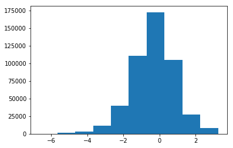

```python
plt.hist(pisa_home['WEALTH'])
```

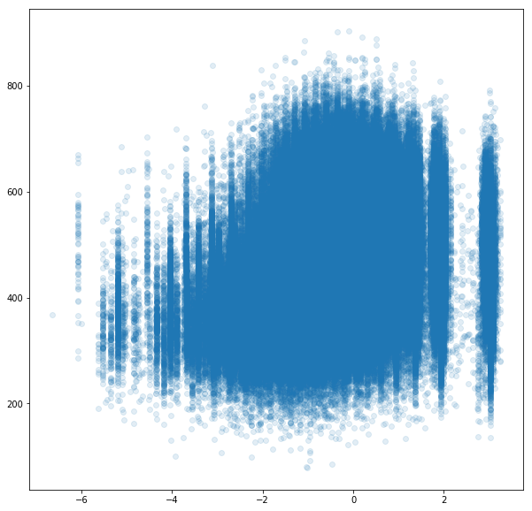

```python
plt.figure(figsize =[10,10])
plt.scatter(data=pisa_home, x = 'WEALTH', y= 'Math_score', alpha = 1/8)
```

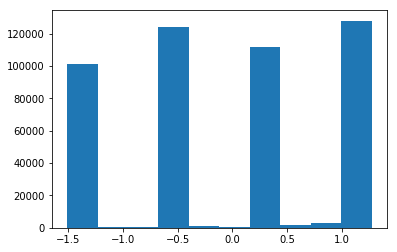

```python
plt.hist(pisa_home['CULTPOS'])
```

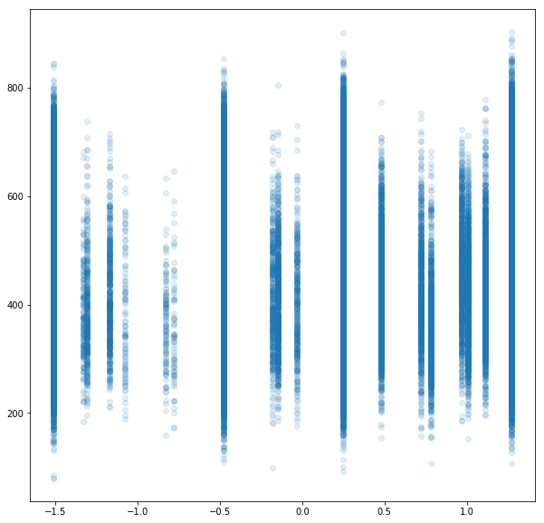

```python
plt.figure(figsize =[10,10])
plt.scatter(data=pisa_home, x = 'CULTPOS', y= 'Math_score', alpha = 1/8)
```

```python
pisa_home['HEDRES'].sum()
```

```
-93376.82999999996
```

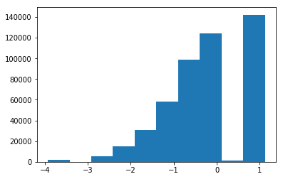

```python
plt.hist(pisa_home['HEDRES'])
```

```python
pisa_home['CULTPOS'].sum()
```

```
-19715.760000000006
```

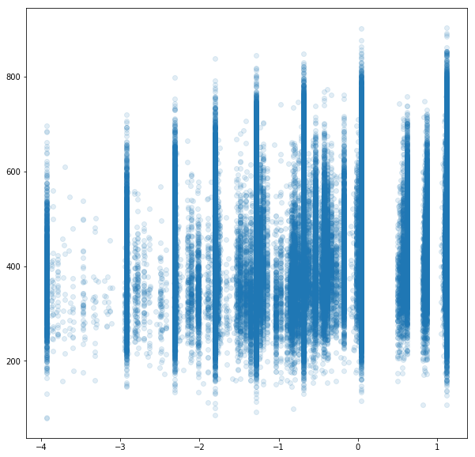

```python
plt.figure(figsize =[10,10])
plt.scatter(data=pisa_home, x = 'HEDRES', y= 'Math_score', alpha = 1/8)
```

> We can see from the hisotgrams that these indexs contain a large amount of negative values, which is not tally with their definition and coding rules. We couldn't find any information explaining the negative values of these indexs neither from the technical report nor internet. The scatterplots couldn't show any meaningful trends either. Therefore, we decided to drop these three variables.

```python
# drop `WEALTH`, `CULTPOS`, AND `HEDRES`
pisa_home.drop(columns = ['WEALTH', 'CULTPOS', 'HEDRES'], inplace = True)
```

## Further Data Wrangling

```python
pisa_home_clean = pisa_home.copy()
```

```python
# Rename columns appropriately
pisa_home_clean.rename({'CNT' : 'Country', 'SCHOOLID':'School_ID', 'STIDSTD':'Student_ID', 'ST04Q01' : 'Gender',
                        'ST11Q01' : 'Live_with_mother', 'ST11Q02' : 'Live_with_father', 'ST15Q01' : 'Mother_job',
                        'ST19Q01' : 'Father_job', 'ST25Q01': 'Language_at_home', 'ST28Q01':'Books_at_home',
                        'IC06Q01':'Int_home_weekday', 'IC07Q01':'Int_home_weekend', 'MISCED':'Edu_level_mother',
                        'FISCED':'Edu_level_father', 'HISCED':'Highest_edu_level_parents'}, axis = 'columns', inplace = True)
```

Since we need to find out whether a student comes from a single-parent family or two-parent family, we will perform feature engineering to create a variable - `Family_status` to tell us this information.

```python
# create a new variable `Family_status`
pisa_home_clean['Family_status'] = pisa_home_clean['Live_with_mother'] + pisa_home_clean['Live_with_father']
```

```python
# define the categories of the new created variable `Family_status`
pisa_home_clean.loc[pisa_home_clean['Family_status'] == "YesYes", 'Family_status'] = 'Live with both'
pisa_home_clean.loc[pisa_home_clean['Family_status'] == "YesNo", 'Family_status'] = 'Live with mother'
pisa_home_clean.loc[pisa_home_clean['Family_status'] == "NoYes", 'Family_status'] = 'Live with father'
pisa_home_clean.loc[pisa_home_clean['Family_status'] == "NoNo", 'Family_status'] = 'Live with none'
```

```python
# Drop the previous columns which won't be used anymore
pisa_home_clean.drop(columns = ['Live_with_mother', 'Live_with_father'], inplace = True)
```

```python
pisa_home_clean['Family_status'].value_counts()
```

```
Live with both      360003
Live with mother     50002
Live with none       18633
Live with father      8262
Name: Family_status, dtype: int64
```

```python
print(pisa_home_clean.shape)
print(pisa_home_clean.info())
pisa_home_clean
```

```
(485490, 19)
<class 'pandas.core.frame.DataFrame'>
RangeIndex: 485490 entries, 0 to 485489
Data columns (total 19 columns):
Unnamed: 0                   485490 non-null int64
Country                      485490 non-null object
OECD                         485490 non-null object
School_ID                    485490 non-null int64
Student_ID                   485490 non-null int64
Gender                       485490 non-null object
Mother_job                   467751 non-null object
Father_job                   451410 non-null object
Language_at_home             465496 non-null object
Books_at_home                473765 non-null object
Int_home_weekday             485490 non-null int64
Int_home_weekend             485490 non-null int64
Edu_level_mother             467085 non-null object
Edu_level_father             452903 non-null object
Highest_edu_level_parents    473091 non-null object
Math_score                   485490 non-null float64
Reading_score                485490 non-null float64
Science_score                485490 non-null float64
Family_status                436900 non-null object
dtypes: float64(3), int64(5), object(11)
memory usage: 70.4+ MB
None
```

|  | Unnamed: 0 | Country | OECD | School_ID | Student_ID | Gender | Mother_job | Father_job | Language_at_home | Books_at_home | Int_home_weekday | Int_home_weekend | Edu_level_mother | Edu_level_father | Highest_edu_level_parents | Math_score | Reading_score | Science_score | Family_status |
| --- | --- | --- | --- | --- | --- | --- | --- | --- | --- | --- | --- | --- | --- | --- | --- | --- | --- | --- | --- |
| 0 | 0 | Albania | Non-OECD | 1 | 1 | Female | Other (e.g. home duties, retired) | Working part-time <for pay> | Language of the test | 0-10 books | 99 | 99 | ISCED 3A, ISCED 4 | ISCED 3A, ISCED 4 | ISCED 3A, ISCED 4 | 366.18634 | 261.01424 | 371.91348 | Live with both |
| 1 | 1 | Albania | Non-OECD | 1 | 2 | Female | Working full-time <for pay> | Working full-time <for pay> | Language of the test | 201-500 books | 99 | 99 | ISCED 5A, 6 | ISCED 3A, ISCED 4 | ISCED 5A, 6 | 470.56396 | 384.68832 | 478.12382 | Live with both |
| 2 | 2 | Albania | Non-OECD | 1 | 3 | Female | Working full-time <for pay> | Working full-time <for pay> | Language of the test | More than 500 books | 99 | 99 | ISCED 5A, 6 | ISCED 5A, 6 | ISCED 5A, 6 | 505.53824 | 405.18154 | 486.60946 | Live with both |
| 3 | 3 | Albania | Non-OECD | 1 | 4 | Female | Working full-time <for pay> | Working full-time <for pay> | Language of the test | 11-25 books | 99 | 99 | ISCED 3B, C | ISCED 5A, 6 | ISCED 5A, 6 | 449.45476 | 477.46376 | 453.97240 | Live with both |
| 4 | 4 | Albania | Non-OECD | 1 | 5 | Female | Working part-time <for pay> | Working part-time <for pay> | Language of the test | 101-200 books | 99 | 99 | None | ISCED 3A, ISCED 4 | ISCED 3A, ISCED 4 | 385.50398 | 256.01010 | 367.15778 | Live with both |
| 5 | 5 | Albania | Non-OECD | 1 | 6 | Female | Not working, but looking for a job | Not working, but looking for a job | Language of the test | 0-10 books | 99 | 99 | ISCED 3B, C | ISCED 2 | ISCED 3B, C | 365.17370 | 337.42688 | 375.55018 | Live with both |
| 6 | 6 | Albania | Non-OECD | 1 | 7 | Female | Working full-time <for pay> | Other (e.g. home duties, retired) | Language of the test | 0-10 books | 99 | 99 | ISCED 5A, 6 | ISCED 3A, ISCED 4 | ISCED 5A, 6 | 490.11528 | 372.13824 | 491.17866 | Live with both |
| 7 | 7 | Albania | Non-OECD | 1 | 8 | Male | Working full-time <for pay> | Working full-time <for pay> | Language of the test | 26-100 books | 99 | 99 | ISCED 5A, 6 | ISCED 5A, 6 | ISCED 5A, 6 | 542.14830 | 516.59478 | 559.06378 | Live with both |
| 8 | 8 | Albania | Non-OECD | 1 | 9 | Female | Working part-time <for pay> | Not working, but looking for a job | Language of the test | 26-100 books | 99 | 99 | ISCED 3A, ISCED 4 | ISCED 5A, 6 | ISCED 5A, 6 | 408.71634 | 326.78312 | 371.72698 | NaN |
| 9 | 9 | Albania | Non-OECD | 2 | 10 | Female | Other (e.g. home duties, retired) | Working part-time <for pay> | Language of the test | 11-25 books | 99 | 99 | ISCED 3A, ISCED 4 | ISCED 3A, ISCED 4 | ISCED 3A, ISCED 4 | 433.87600 | 401.92486 | 342.16710 | Live with both |
| 10 | 10 | Albania | Non-OECD | 2 | 11 | Female | Working full-time <for pay> | Other (e.g. home duties, retired) | Language of the test | 201-500 books | 99 | 99 | ISCED 5A, 6 | ISCED 5A, 6 | ISCED 5A, 6 | 438.93910 | 551.49346 | 459.66058 | Live with both |
| 11 | 11 | Albania | Non-OECD | 2 | 12 | Female | Working full-time <for pay> | Working full-time <for pay> | Language of the test | 0-10 books | 99 | 99 | ISCED 3A, ISCED 4 | ISCED 3A, ISCED 4 | ISCED 3A, ISCED 4 | 268.35178 | 208.03376 | 259.92168 | Live with both |
| 12 | 12 | Albania | Non-OECD | 2 | 13 | Female | Other (e.g. home duties, retired) | Working full-time <for pay> | Language of the test | 0-10 books | 99 | 99 | ISCED 2 | None | ISCED 2 | 231.89750 | 178.88258 | 194.36778 | Live with both |
| 13 | 13 | Albania | Non-OECD | 2 | 14 | Female | Other (e.g. home duties, retired) | Working full-time <for pay> | Language of the test | 0-10 books | 99 | 99 | ISCED 3A, ISCED 4 | ISCED 3A, ISCED 4 | ISCED 3A, ISCED 4 | 448.20844 | 502.24622 | 505.35248 | Live with both |
| 14 | 14 | Albania | Non-OECD | 2 | 15 | Male | Other (e.g. home duties, retired) | NaN | Language of the test | NaN | 99 | 99 | ISCED 2 | ISCED 5A, 6 | ISCED 5A, 6 | 297.25036 | 283.22874 | 294.42372 | Live with none |
| 15 | 15 | Albania | Non-OECD | 2 | 16 | Male | Other (e.g. home duties, retired) | Working full-time <for pay> | Language of the test | 0-10 books | 99 | 99 | ISCED 5A, 6 | ISCED 5A, 6 | ISCED 5A, 6 | 367.43262 | 375.05146 | 377.41516 | Live with both |
| 16 | 16 | Albania | Non-OECD | 2 | 17 | Female | Other (e.g. home duties, retired) | Not working, but looking for a job | Language of the test | 11-25 books | 99 | 99 | ISCED 2 | ISCED 3A, ISCED 4 | ISCED 3A, ISCED 4 | 245.99622 | 188.89090 | 225.97912 | Live with both |
| 17 | 17 | Albania | Non-OECD | 2 | 18 | Male | Other (e.g. home duties, retired) | Other (e.g. home duties, retired) | Language of the test | 0-10 books | 99 | 99 | ISCED 2 | ISCED 2 | ISCED 2 | 527.27062 | 558.77706 | 500.78328 | NaN |
| 18 | 18 | Albania | Non-OECD | 2 | 19 | Female | Working full-time <for pay> | Working full-time <for pay> | Language of the test | 11-25 books | 99 | 99 | ISCED 5A, 6 | ISCED 5A, 6 | ISCED 5A, 6 | 416.81728 | 350.37414 | 360.07088 | Live with both |
| 19 | 19 | Albania | Non-OECD | 2 | 20 | Female | Other (e.g. home duties, retired) | Working full-time <for pay> | Language of the test | 201-500 books | 99 | 99 | ISCED 3A, ISCED 4 | ISCED 3A, ISCED 4 | ISCED 3A, ISCED 4 | 453.19364 | 458.00314 | 451.82768 | Live with both |
| 20 | 20 | Albania | Non-OECD | 2 | 21 | Female | Other (e.g. home duties, retired) | Working full-time <for pay> | Language of the test | 0-10 books | 99 | 99 | ISCED 3A, ISCED 4 | ISCED 5A, 6 | ISCED 5A, 6 | 396.56488 | 428.37540 | 394.94592 | Live with both |
| 21 | 21 | Albania | Non-OECD | 2 | 22 | Male | Working part-time <for pay> | Working part-time <for pay> | Language of the test | 26-100 books | 99 | 99 | ISCED 2 | ISCED 3A, ISCED 4 | ISCED 3A, ISCED 4 | 393.05968 | 440.32980 | 409.02648 | Live with both |
| 22 | 22 | Albania | Non-OECD | 2 | 23 | Female | Other (e.g. home duties, retired) | Working full-time <for pay> | Language of the test | 26-100 books | 99 | 99 | ISCED 2 | ISCED 2 | ISCED 2 | 230.41752 | 264.74752 | 262.62588 | Live with both |
| 23 | 23 | Albania | Non-OECD | 2 | 24 | Female | Other (e.g. home duties, retired) | Working full-time <for pay> | Language of the test | 0-10 books | 99 | 99 | ISCED 2 | ISCED 5B | ISCED 5B | 442.60008 | 412.64804 | 435.88214 | Live with both |
| 24 | 24 | Albania | Non-OECD | 2 | 25 | Male | Other (e.g. home duties, retired) | Working full-time <for pay> | Language of the test | 0-10 books | 99 | 99 | ISCED 2 | ISCED 2 | ISCED 2 | 314.15328 | 329.01980 | 304.86756 | Live with both |
| 25 | 25 | Albania | Non-OECD | 2 | 26 | Female | Not working, but looking for a job | Working full-time <for pay> | Language of the test | 11-25 books | 99 | 99 | ISCED 2 | ISCED 3A, ISCED 4 | ISCED 3A, ISCED 4 | 373.19676 | 364.51284 | 374.61766 | Live with both |
| 26 | 26 | Albania | Non-OECD | 2 | 27 | Female | Other (e.g. home duties, retired) | Other (e.g. home duties, retired) | Language of the test | 11-25 books | 99 | 99 | ISCED 3A, ISCED 4 | ISCED 5A, 6 | ISCED 5A, 6 | 385.11450 | 398.27102 | 400.35434 | Live with both |
| 27 | 27 | Albania | Non-OECD | 2 | 28 | Male | Other (e.g. home duties, retired) | Working full-time <for pay> | Language of the test | 201-500 books | 99 | 99 | ISCED 5A, 6 | ISCED 5A, 6 | ISCED 5A, 6 | 405.28900 | 412.50230 | 395.59866 | Live with both |
| 28 | 28 | Albania | Non-OECD | 2 | 29 | Female | Other (e.g. home duties, retired) | Working part-time <for pay> | NaN | 26-100 books | 99 | 99 | ISCED 2 | ISCED 2 | ISCED 2 | 364.23900 | 323.28816 | 289.38830 | Live with none |
| 29 | 29 | Albania | Non-OECD | 2 | 30 | Female | Working full-time <for pay> | Working full-time <for pay> | Language of the test | 26-100 books | 99 | 99 | ISCED 5A, 6 | ISCED 5A, 6 | ISCED 5A, 6 | 521.50646 | 536.56042 | 528.66468 | Live with both |
| ... | ... | ... | ... | ... | ... | ... | ... | ... | ... | ... | ... | ... | ... | ... | ... | ... | ... | ... | ... |
| 485460 | 485460 | Vietnam | Non-OECD | 162 | 4930 | Male | Other (e.g. home duties, retired) | Other (e.g. home duties, retired) | Language of the test | 101-200 books | 97 | 97 | ISCED 1 | None | ISCED 1 | 467.05870 | 432.87170 | 509.82842 | Live with both |
| 485461 | 485461 | Vietnam | Non-OECD | 162 | 4931 | Male | Other (e.g. home duties, retired) | Working full-time <for pay> | Language of the test | 0-10 books | 97 | 97 | None | None | None | 573.30582 | 499.59354 | 573.98360 | Live with both |
| 485462 | 485462 | Vietnam | Non-OECD | 162 | 4932 | Female | NaN | Other (e.g. home duties, retired) | Language of the test | 26-100 books | 97 | 97 | NaN | None | None | 448.44212 | 488.82240 | 516.07610 | Live with father |
| 485463 | 485463 | Vietnam | Non-OECD | 162 | 4933 | Male | Working full-time <for pay> | Working full-time <for pay> | Language of the test | 101-200 books | 97 | 97 | None | ISCED 5A, 6 | ISCED 5A, 6 | 526.72534 | 470.24234 | 572.49162 | Live with both |
| 485464 | 485464 | Vietnam | Non-OECD | 162 | 4934 | Male | Working full-time <for pay> | Not working, but looking for a job | Language of the test | 11-25 books | 97 | 97 | ISCED 2 | ISCED 2 | ISCED 2 | 517.06652 | 488.84746 | 532.20812 | Live with both |
| 485465 | 485465 | Vietnam | Non-OECD | 162 | 4935 | Male | Other (e.g. home duties, retired) | Working full-time <for pay> | Language of the test | 26-100 books | 97 | 97 | None | None | None | 508.03084 | 534.39794 | 575.28908 | Live with both |
| 485466 | 485466 | Vietnam | Non-OECD | 162 | 4936 | Male | Working part-time <for pay> | Working full-time <for pay> | Language of the test | 101-200 books | 97 | 97 | None | None | None | 504.44774 | 421.16328 | 553.46886 | Live with both |
| 485467 | 485467 | Vietnam | Non-OECD | 162 | 4937 | Female | Working full-time <for pay> | Working part-time <for pay> | Language of the test | 0-10 books | 97 | 97 | None | ISCED 1 | ISCED 1 | 445.17060 | 491.44360 | 462.73778 | Live with both |
| 485468 | 485468 | Vietnam | Non-OECD | 162 | 4938 | Female | Working part-time <for pay> | Working part-time <for pay> | Language of the test | 0-10 books | 97 | 97 | None | ISCED 1 | ISCED 1 | 495.72362 | 472.14190 | 537.43006 | Live with both |
| 485469 | 485469 | Vietnam | Non-OECD | 162 | 4939 | Female | Working full-time <for pay> | Working full-time <for pay> | Language of the test | 11-25 books | 97 | 97 | None | None | None | 414.48042 | 437.19222 | 495.00184 | Live with both |
| 485470 | 485470 | Vietnam | Non-OECD | 162 | 4940 | Male | Other (e.g. home duties, retired) | Other (e.g. home duties, retired) | Language of the test | 0-10 books | 97 | 97 | ISCED 1 | None | ISCED 1 | 411.44260 | 400.15234 | 472.34242 | Live with both |
| 485471 | 485471 | Vietnam | Non-OECD | 162 | 4941 | Male | NaN | Working full-time <for pay> | Language of the test | 0-10 books | 97 | 97 | ISCED 2 | ISCED 3A, ISCED 4 | ISCED 3A, ISCED 4 | 498.44992 | 503.84386 | 530.52964 | Live with mother |
| 485472 | 485472 | Vietnam | Non-OECD | 162 | 4942 | Male | Other (e.g. home duties, retired) | Working part-time <for pay> | Language of the test | 11-25 books | 97 | 97 | ISCED 1 | ISCED 1 | ISCED 1 | 542.14830 | 466.07222 | 573.98358 | Live with both |
| 485473 | 485473 | Vietnam | Non-OECD | 162 | 4943 | Female | Working full-time <for pay> | Working full-time <for pay> | Language of the test | 0-10 books | 97 | 97 | ISCED 1 | ISCED 2 | ISCED 2 | 471.88814 | 468.32920 | 502.74152 | Live with both |
| 485474 | 485474 | Vietnam | Non-OECD | 162 | 4944 | Male | Working part-time <for pay> | Working part-time <for pay> | Language of the test | 0-10 books | 97 | 97 | ISCED 2 | NaN | ISCED 2 | 422.81508 | 426.29576 | 472.52892 | Live with both |
| 485475 | 485475 | Vietnam | Non-OECD | 162 | 4945 | Male | Working part-time <for pay> | Other (e.g. home duties, retired) | Language of the test | 26-100 books | 97 | 97 | None | None | None | 437.30332 | 469.11960 | 492.11116 | Live with both |
| 485476 | 485476 | Vietnam | Non-OECD | 162 | 4946 | Female | Other (e.g. home duties, retired) | Other (e.g. home duties, retired) | Language of the test | 0-10 books | 97 | 97 | ISCED 2 | ISCED 2 | ISCED 2 | 435.35598 | 454.19046 | 493.32340 | Live with both |
| 485477 | 485477 | Vietnam | Non-OECD | 162 | 4947 | Female | Other (e.g. home duties, retired) | Working full-time <for pay> | Language of the test | 11-25 books | 97 | 97 | None | ISCED 1 | ISCED 1 | 469.00608 | 476.11344 | 499.01154 | Live with both |
| 485478 | 485478 | Vietnam | Non-OECD | 162 | 4948 | Female | Other (e.g. home duties, retired) | Other (e.g. home duties, retired) | Language of the test | 101-200 books | 97 | 97 | ISCED 1 | None | ISCED 1 | 441.04222 | 469.12348 | 494.90860 | Live with both |
| 485479 | 485479 | Vietnam | Non-OECD | 162 | 4949 | Male | Other (e.g. home duties, retired) | NaN | Language of the test | 101-200 books | 97 | 97 | ISCED 1 | ISCED 5A, 6 | ISCED 5A, 6 | 462.93038 | 476.81830 | 511.04064 | Live with mother |
| 485480 | 485480 | Vietnam | Non-OECD | 162 | 4950 | Male | Other (e.g. home duties, retired) | Working full-time <for pay> | Language of the test | 0-10 books | 97 | 97 | ISCED 2 | ISCED 5A, 6 | ISCED 5A, 6 | 406.14584 | 450.51448 | 508.89594 | Live with both |
| 485481 | 485481 | Vietnam | Non-OECD | 162 | 4951 | Male | Other (e.g. home duties, retired) | Other (e.g. home duties, retired) | Language of the test | 0-10 books | 97 | 97 | ISCED 3A, ISCED 4 | ISCED 3A, ISCED 4 | ISCED 3A, ISCED 4 | 377.40304 | 440.16940 | 456.49012 | Live with both |
| 485482 | 485482 | Vietnam | Non-OECD | 162 | 4952 | Female | Working full-time <for pay> | Working full-time <for pay> | Language of the test | 26-100 books | 97 | 97 | ISCED 3A, ISCED 4 | ISCED 3A, ISCED 4 | ISCED 3A, ISCED 4 | 451.01262 | 490.72874 | 490.99216 | Live with none |
| 485483 | 485483 | Vietnam | Non-OECD | 162 | 4953 | Female | Working full-time <for pay> | Working full-time <for pay> | Language of the test | 26-100 books | 97 | 97 | ISCED 3A, ISCED 4 | ISCED 3A, ISCED 4 | ISCED 3A, ISCED 4 | 522.83066 | 500.89590 | 531.92838 | Live with mother |
| 485484 | 485484 | Vietnam | Non-OECD | 162 | 4954 | Male | Other (e.g. home duties, retired) | Other (e.g. home duties, retired) | Language of the test | 26-100 books | 97 | 97 | None | ISCED 1 | ISCED 1 | 507.79718 | 467.35532 | 499.10482 | Live with both |
| 485485 | 485485 | Vietnam | Non-OECD | 162 | 4955 | Female | Other (e.g. home duties, retired) | Other (e.g. home duties, retired) | Language of the test | 26-100 books | 97 | 97 | ISCED 2 | None | ISCED 2 | 486.22058 | 472.61846 | 536.31110 | Live with both |
| 485486 | 485486 | Vietnam | Non-OECD | 162 | 4956 | Male | Other (e.g. home duties, retired) | Other (e.g. home duties, retired) | Language of the test | 26-100 books | 97 | 97 | None | ISCED 2 | ISCED 2 | 529.21794 | 487.24356 | 524.37522 | Live with both |
| 485487 | 485487 | Vietnam | Non-OECD | 162 | 4957 | Male | Working full-time <for pay> | Working full-time <for pay> | Language of the test | 0-10 books | 97 | 97 | ISCED 1 | ISCED 2 | ISCED 2 | 486.29850 | 476.25694 | 541.90600 | Live with both |
| 485488 | 485488 | Vietnam | Non-OECD | 162 | 4958 | Male | Other (e.g. home duties, retired) | Other (e.g. home duties, retired) | Language of the test | 26-100 books | 97 | 97 | ISCED 2 | ISCED 5A, 6 | ISCED 5A, 6 | 522.90856 | 518.43922 | 526.70646 | Live with both |
| 485489 | 485489 | Vietnam | Non-OECD | 162 | 4959 | Female | Other (e.g. home duties, retired) | Working full-time <for pay> | Language of the test | 0-10 books | 97 | 97 | None | ISCED 3A, ISCED 4 | ISCED 3A, ISCED 4 | 454.43994 | 488.66354 | 492.95038 | Live with mother |

485490 rows × 19 columns

The dataframe info shows that some variables have NaN data. In statistical language, if the number of the cases is less than 5% of the sample, which is in most cases of this study, then the researcher can drop them. In the case of multivariate analysis, if there is a larger number of missing values, then it can be better to drop those cases (rather than do imputation) and replace them.

### What is the structure of your dataset?

There are *485490* observations in the dataset with *636* variables.

### What is/are the main feature(s) of interest in your dataset?

The dataset consisted of with *636* variables. After looking into the raw data and data dictionary, we decided to focus on the effects of family-based factors(e.g., language at home, household possessions, family status, parents' working status, and parents' education levels) on the students' academic performance. We will also look into the difference among countrie.

### What features in the dataset do you think will help support your investigation into your feature(s) of interest?

I expect that family status, parents' working status, and parents' education levels will have significant effect on the test scores. I also think that the other family-based factors will have effects on the scores, though to a much smaller degree. We are also interested to see the difference among countries.

## Univariate Exploration and Analysis

*In this section, we will investigate the distributions of individual variables.*

### Distribution of test scores

> First, let's take a look at the distribution of PISA2012 scores for each subject across students.

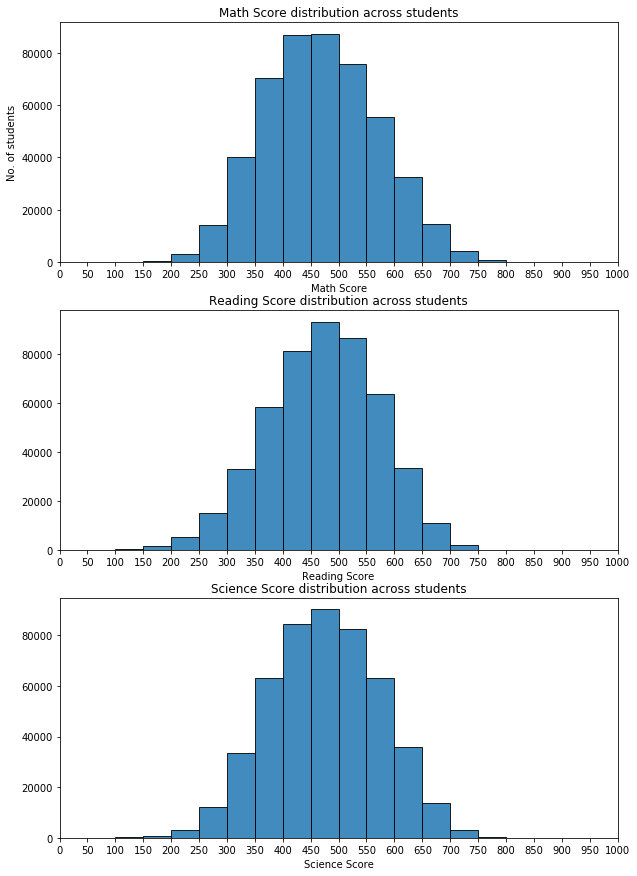

```python
# generate subplots of distributions of Math_score, Reading_score, and Science_score
plt.figure(figsize = [10,15])

bins_hist = np.arange(0, 1000 + 1, 50)

plt.subplot(3, 1, 1)
plt.hist(pisa_home_clean['Math_score'], bins = bins_hist, ec = 'black', alpha = 0.85);
plt.xlim(0, 1000);
plt.xticks(bins_hist)
plt.xlabel('Math Score');
plt.ylabel('No. of students')
plt.title("Math Score distribution across students");

plt.subplot(3, 1, 2)
plt.hist(pisa_home_clean['Reading_score'], bins = bins_hist, ec = 'black', alpha = 0.85);
plt.xlim(0, 1000);
plt.xticks(bins_hist)
plt.xlabel('Reading Score');
plt.title("Reading Score distribution across students");

plt.subplot(3, 1, 3)
plt.hist(pisa_home_clean['Science_score'], bins = bins_hist, ec = 'black', alpha = 0.85);
plt.xlim(0, 1000);
plt.xticks(bins_hist)
plt.xlabel('Science Score');
plt.title("Science Score distribution across students");
```

We can tell that the scores of all three subject follow the normal distribution perfectly, which approves the validity of this test.

### Distribution of Family-based Categorical Variables

> We would also like to see the distribution of the categorical variables we are interested in. Moreover, for each categorical variable, we would like to see the frequency of each category in a certain order. The best thing for us to do is to convert the categorical variables into ordered categorical data type. By doing this, the order of categories becomes innate to the feature, and we don't need to specify an "order" parameter each time we plot them.

```python
# remove the trailing spaces for volumns 'Books_at_home', 'Mother_job', and 'Father_job'
pisa_home_clean['Books_at_home'] = pisa_home_clean['Books_at_home'].str.rstrip()
pisa_home_clean['Mother_job'] = pisa_home_clean['Mother_job'].str.rstrip()
pisa_home_clean['Father_job'] = pisa_home_clean['Father_job'].str.rstrip()
```

```python
# convert 'Family_status', 'Books_at_home', 'Edu_level_mother', 'Edu_level_father', 'Highest_edu_level_parents'
# 'Mother_job', 'Father_job' into ordered categorical types
ordinal_var_dict = {'Family_status': ['Live with both', 'Live with mother', 'Live with father', 'Live with none'],
                    'Books_at_home': ['0-10 books', '11-25 books', '26-100 books', '101-200 books', '201-500 books',
                                      'More than 500 books'],
                    'Edu_level_mother': ['None','ISCED 1','ISCED 2','ISCED 3B, C', 'ISCED 3A, ISCED 4','ISCED 5A, 6'],
                    'Edu_level_father': ['None','ISCED 1','ISCED 2','ISCED 3B, C', 'ISCED 3A, ISCED 4','ISCED 5A, 6'],
                    'Highest_edu_level_parents': ['None','ISCED 1','ISCED 2','ISCED 3B, C', 'ISCED 3A, ISCED 4','ISCED 5A, 6'],
                    'Mother_job': ['Working full-time <for pay>', 'Working part-time <for pay>',
                                   'Not working, but looking for a job', 'Other (e.g. home duties, retired)'],
                    'Father_job': ['Working full-time <for pay>', 'Working part-time <for pay>',
                                   'Not working, but looking for a job', 'Other (e.g. home duties, retired)']}

for var in ordinal_var_dict:
    ordered_var = pd.api.types.CategoricalDtype(ordered = True, categories = ordinal_var_dict[var])
    pisa_home_clean[var] = pisa_home_clean[var].astype(ordered_var)
```

```python
pisa_home_clean.to_csv('pisa_home_clean.csv')
```

#### Family Status

```python
pisa_home_clean['Family_status'].value_counts()
```

```
Live with both      360003
Live with mother     50002
Live with none       18633
Live with father      8262
Name: Family_status, dtype: int64
```

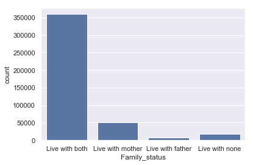

```python
# plot the distribution of `Family_status`
base_color = sb.color_palette()[0]
sb.countplot(data = pisa_home_clean, x = 'Family_status', color= base_color)
```

The majority of participants lived with both parents, followed by live with mother only. We are interested to see the distribution of subject scores on each categorical level.

#### Parent Employment Status

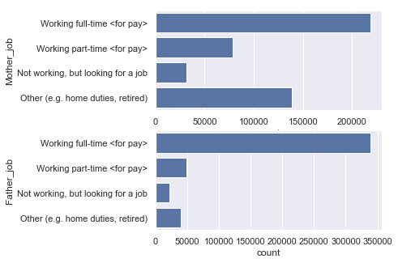

```python
# plot distribution of parent employment status

plt.figure(figsize = [5,5])
base_color = sb.color_palette()[0]
plt.subplot(2, 1, 1)
sb.countplot(data=pisa_home_clean, y ='Mother_job', color = base_color)

plt.subplot(2, 1, 2)
sb.countplot(data=pisa_home_clean, y ='Father_job', color = base_color)
```

#### Language at Home

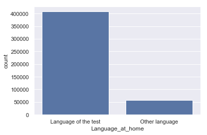

```python
# plot the distribution of Language_at_home

base_color = sb.color_palette()[0]
sb.countplot(data = pisa_home_clean, x = 'Language_at_home', color= base_color)
```

The majority of participants speak the same language at home as in the test.

#### Number of Books at Home

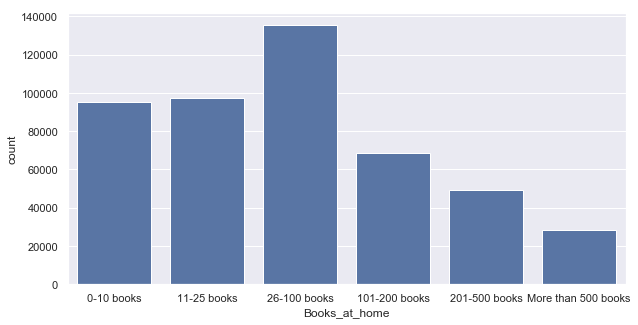

```python
# plot the distribution of Books_at_home
plt.figure(figsize = [10, 5])
base_color = sb.color_palette()[0]
sb.countplot(data = pisa_home_clean, x = 'Books_at_home', color= base_color)
```

#### Parents Educational Level

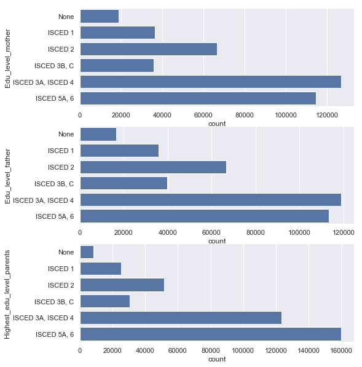

```python
#plot the distribution of parents educational level
plt.figure(figsize = [8,10])
base_color = sb.color_palette()[0]
plt.subplot(3, 1, 1)
sb.countplot(data=pisa_home_clean, y ='Edu_level_mother', color = base_color)

plt.subplot(3, 1, 2)
sb.countplot(data=pisa_home_clean, y ='Edu_level_father', color = base_color)

plt.subplot(3, 1, 3)
sb.countplot(data=pisa_home_clean, y ='Highest_edu_level_parents', color = base_color)
```

Most parents of the participants are well educated with the educational level equals to or higher than ISCED 3A/4.

```python
pisa_home_clean.to_csv('pisa_home_clean.csv')
```

### Discuss the distribution(s) of your variable(s) of interest. Were there any unusual points? Did you need to perform any transformations?

The three numerical variables (i.e. Math_score, Reading_score, Science_score) we investigated in this section follow the normal distribution perfectly, which approves the validity of this test. The other variables we are interested in are all categorical variables. The distributions show the family-related features of our dataset. There is no unusual points identified. There is no need to transform any variable.

### Of the features you investigated, were there any unusual distributions? Did you perform any operations on the data to tidy, adjust, or change the form of the data? If so, why did you do this?

For each categorical variable, we would like to see the frequency of each category in a certain order. Therefore, we convert the categorical variables into ordered categorical data type. By doing this, the order of categories becomes innate to the feature, and we don't need to specify an "order" parameter each time we plot them.

## Bivariate Exploration

> In this section, we will investigate relationships between pairs of variables in our dataset.

### Country vs. Score

> How do the scores distribute among countries? Which countries are the leaders in terms of academic performance?

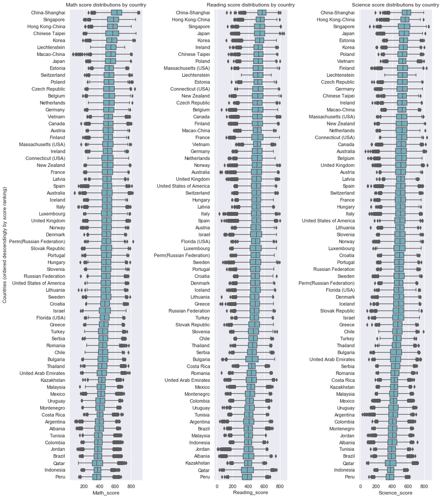

```python
# plot the distribution of all subject scores by country with descending order by score ranking

plt.figure(figsize = [15, 20])
plt.subplots_adjust(wspace = 0.98) # adjust spacing between subplots, in order to show long country names nicely

math_score_country_order = pisa_home_clean.groupby('Country')['Math_score'].mean().sort_values(ascending = False).index
reading_score_country_order = pisa_home_clean.groupby('Country')['Reading_score'].mean().sort_values(ascending = False).index
science_score_country_order = pisa_home_clean.groupby('Country')['Science_score'].mean().sort_values(ascending = False).index

plt.subplot(1, 3, 1)
sb.boxplot(data = pisa_home_clean, x = 'Math_score', y = 'Country', order = math_score_country_order, color = sb.color_palette()[9]);
plt.ylabel('Countries (ordered descendingly by score ranking)')
plt.title('Math score distributions by country');

plt.subplot(1, 3, 2)
sb.boxplot(data = pisa_home_clean, x = 'Reading_score', y = 'Country', order = reading_score_country_order, color = sb.color_palette()[9]);
plt.ylabel(''); # Remove the redundant label
plt.title('Reading score distributions by country');

plt.subplot(1, 3, 3)
sb.boxplot(data = pisa_home_clean, x = 'Science_score', y = 'Country', order = science_score_country_order, color = sb.color_palette()[9]);
plt.ylabel(''); # Remove the redundant label
plt.title('Science score distributions by country');
```

We plotted the score as boxchart for each country according to the decreasing order ranked by the average performance of countries. We noticed that:

- *Most countries ranking from 10th to 40th seem to perform comparably to each other.*
- *The top players outperform significantly over the other countries for all three subjects, espcially the 1st player - China-Shanghai.*
- *The box-and-wiskers plot allows us to see the outliers for each country. For example, we find that, the outstanding results of math come from China-Shanghai, while the outstanding results of reading come from Japan, and that of science from Singapore. Although it's not the focus of this study, the underlying reasons can be explored by checking the influencing factors of the difference among countries.*

### Language at Home vs. Score

> Does language students speak at home influence their test scores?

```
 <a list of 10 Text yticklabel objects>)
```

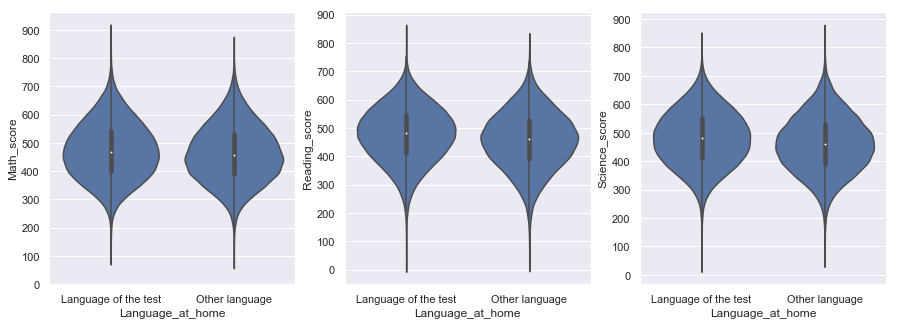

```python
# plot the scores by language_at_home

plt.figure(figsize = [15,5])
default_color = sb.color_palette()[0]
bins_hist = np.arange(0, 1000, 100)

plt.subplot(1, 3, 1)
sb.violinplot(data = pisa_home_clean, x = 'Language_at_home', y = 'Math_score', color = default_color)
plt.yticks(bins_hist)
plt.subplot(1, 3, 2)
sb.violinplot(data = pisa_home_clean, x = 'Language_at_home', y = 'Reading_score', color = default_color)
plt.yticks(bins_hist)
plt.subplot(1, 3, 3)
sb.violinplot(data = pisa_home_clean, x = 'Language_at_home', y = 'Science_score', color = default_color)
plt.yticks(bins_hist)
```

There is no significant difference between these two categories.

### Possession of Books vs. Score

> Books at home is derived as one of the indicators of household possessions. People tend to believe that people live in a family which has a better educational resource tend to perform better in academic than people who don't.

```
 <a list of 10 Text yticklabel objects>)
```

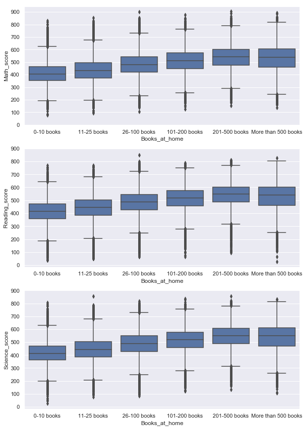

```python
#plot the scores by possession of books

plt.figure(figsize = [10,15])
default_color = sb.color_palette()[0]
bins_hist = np.arange(0, 1000, 100)
plt.suptitle('Possession of Books vs. Scores', y = 0.92 , fontsize = 'xx-large')
plt.subplot(3, 1, 1)
sb.boxplot(data = pisa_home_clean, x = 'Books_at_home', y = 'Math_score', color = default_color)
plt.yticks(bins_hist)
plt.subplot(3, 1, 2)
sb.boxplot(data = pisa_home_clean, x = 'Books_at_home', y = 'Reading_score', color = default_color)
plt.yticks(bins_hist)
plt.subplot(3, 1, 3)
sb.boxplot(data = pisa_home_clean, x = 'Books_at_home', y = 'Science_score', color = default_color)
plt.yticks(bins_hist)
```

The results shows that students with more books at home score better on tests of all subjects.

### Family Status vs. Scores

> In this study, we define the family status as whether the participants live in a two-parents family, one parents family (live with mother only/live with father only), or no parents family. We are interested to see if the family status is an important predictors of academic achievement.

```
 <a list of 10 Text xticklabel objects>)
```

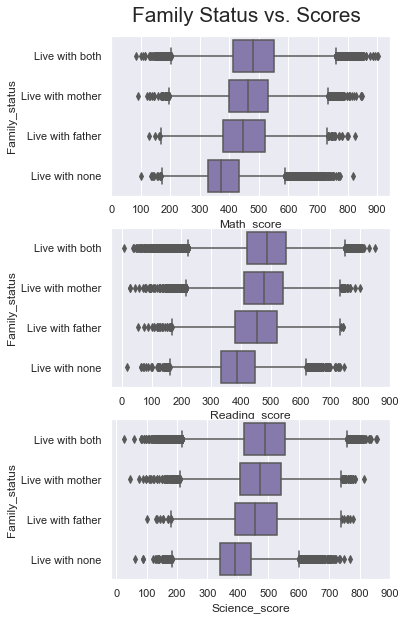

```python
# plot the scores by Family_status

plt.figure(figsize = [5,10])
default_color = sb.color_palette()[4]
bins_hist = np.arange(0, 1000, 100)
plt.suptitle('Family Status vs. Scores', y = 0.92 , fontsize = 'xx-large')
plt.subplot(3, 1, 1)
sb.boxplot(data = pisa_home_clean, y = 'Family_status', x = 'Math_score', color = default_color)
plt.xticks(bins_hist)
plt.subplot(3, 1, 2)
sb.boxplot(data = pisa_home_clean, y = 'Family_status', x = 'Reading_score', color = default_color)
plt.xticks(bins_hist)
plt.subplot(3, 1, 3)
sb.boxplot(data = pisa_home_clean, y = 'Family_status', x = 'Science_score', color = default_color)
plt.xticks(bins_hist)
```

The results show that, in general, students in homes with two parents do better in all three subjects. Students in a single parent household tend to do better when that parent is the Mother. Students with neither parent living at home have the lowest achievement. Does this phenomenon exist in all countries? We will discuss this in further details in multivariate section.

### Parents Employment Status vs. Score

> We are interested to see if parents' employment status influence their children's academic performance.

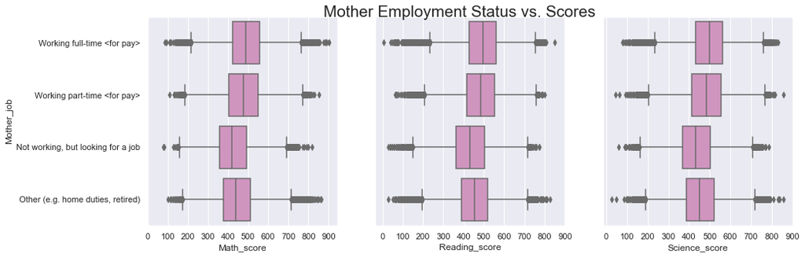

```python
# plot the scores by mother employmeent status

plt.figure(figsize = [15,5])
job_color = sb.color_palette()[6]
bins_hist = np.arange(0, 1000, 100)
plt.suptitle('Mother Employment Status vs. Scores', y = 0.92 , fontsize = 'xx-large')

plt.subplot(1, 3, 1)
sb.boxplot(data = pisa_home_clean, y = 'Mother_job', x = 'Math_score', color = job_color)
plt.xticks(bins_hist)

plt.subplot(1, 3, 2)
sb.boxplot(data = pisa_home_clean, y = 'Mother_job', x = 'Reading_score', color = job_color)
plt.xticks(bins_hist)
plt.yticks([])
plt.ylabel('')

plt.subplot(1, 3, 3)
sb.boxplot(data = pisa_home_clean, y = 'Mother_job', x = 'Science_score', color = job_color)
plt.xticks(bins_hist)
plt.yticks([])
plt.ylabel('')
```

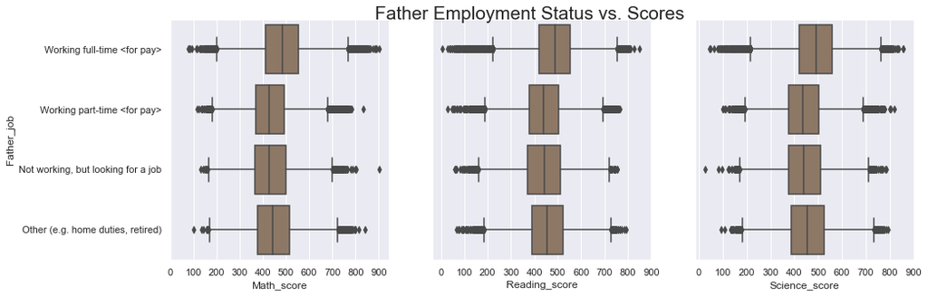

```python
# plot the scores by father employmeent status

plt.figure(figsize = [15,5])
job_color = sb.color_palette()[5]
bins_hist = np.arange(0, 1000, 100)
plt.suptitle('Father Employment Status vs. Scores', y = 0.92 , fontsize = 'xx-large')

plt.subplot(1, 3, 1)
sb.boxplot(data = pisa_home_clean, y = 'Father_job', x = 'Math_score', color = job_color)
plt.xticks(bins_hist)

plt.subplot(1, 3, 2)
sb.boxplot(data = pisa_home_clean, y = 'Father_job', x = 'Reading_score', color = job_color)
plt.xticks(bins_hist)
plt.yticks([])
plt.ylabel('')

plt.subplot(1, 3, 3)
sb.boxplot(data = pisa_home_clean, y = 'Father_job', x = 'Science_score', color = job_color)
plt.xticks(bins_hist)
plt.yticks([])
plt.ylabel('')
```

Students with fully employed parents do better in tests. Having a mother who works part-time or full-time is associated with test outcomes. Students with a father employed less than full-time have lower test scores than if the father had a full-time postion. A stay-at-home (Other) parent does not improve scores. It will be interesting to see if the finding is consistent across different countries.

### Parents Education Level vs. Scores

> We are interested to see if parents' education level influence their children's academic performance.

```
 <a list of 10 Text yticklabel objects>)
```

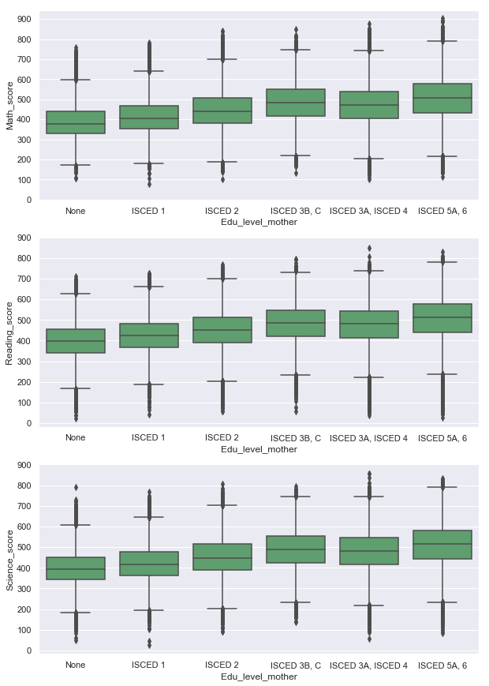

```python
# plot the scores by mother education level

plt.figure(figsize = [10,15])
default_color = sb.color_palette()[2]
bins_hist = np.arange(0, 1000, 100)

plt.subplot(3, 1, 1)
sb.boxplot(data = pisa_home_clean, x = 'Edu_level_mother', y = 'Math_score', color = default_color)
plt.yticks(bins_hist)
plt.subplot(3, 1, 2)
sb.boxplot(data = pisa_home_clean, x = 'Edu_level_mother', y = 'Reading_score', color = default_color)
plt.yticks(bins_hist)
plt.subplot(3, 1, 3)
sb.boxplot(data = pisa_home_clean, x = 'Edu_level_mother', y = 'Science_score', color = default_color)
plt.yticks(bins_hist)
```

```
 <a list of 10 Text yticklabel objects>)
```

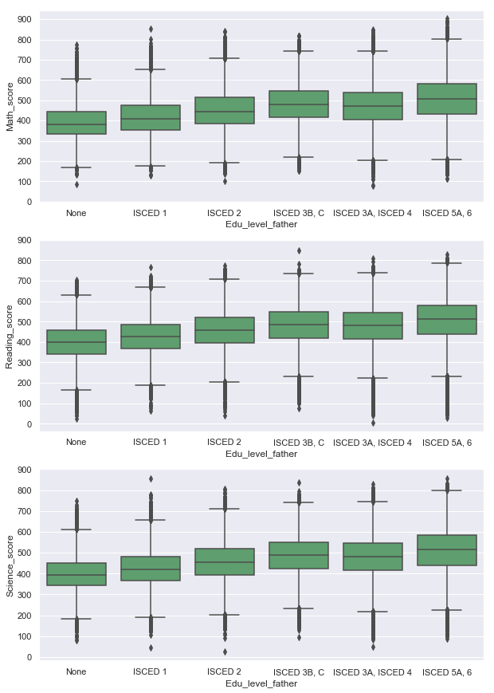

```python
# plot the scores by father education level
plt.figure(figsize = [10,15])
default_color = sb.color_palette()[2]
bins_hist = np.arange(0, 1000, 100)

plt.subplot(3, 1, 1)
sb.boxplot(data = pisa_home_clean, x = 'Edu_level_father', y = 'Math_score', color = default_color)
plt.yticks(bins_hist)
plt.subplot(3, 1, 2)
sb.boxplot(data = pisa_home_clean, x = 'Edu_level_father', y = 'Reading_score', color = default_color)
plt.yticks(bins_hist)
plt.subplot(3, 1, 3)
sb.boxplot(data = pisa_home_clean, x = 'Edu_level_father', y = 'Science_score', color = default_color)
plt.yticks(bins_hist)
```

```
 <a list of 10 Text yticklabel objects>)
```

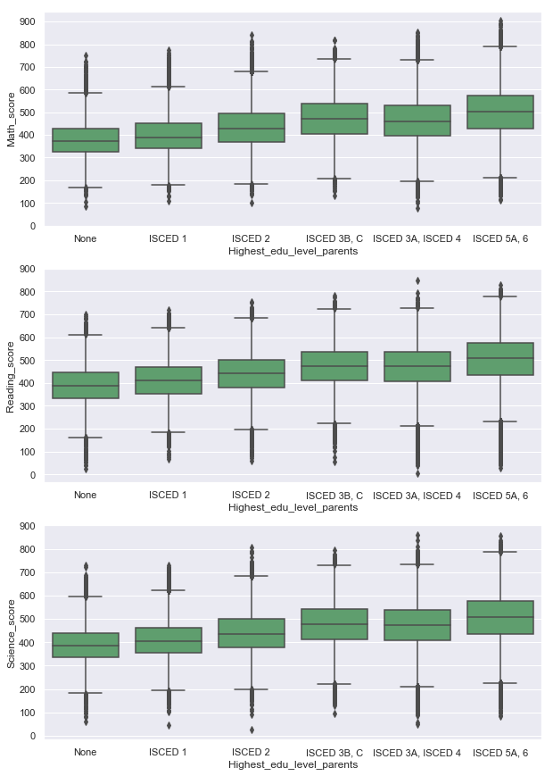

```python
# plot the scores by highest education level of parents

plt.figure(figsize = [10,15])
job_color = sb.color_palette()[2]
bins_hist = np.arange(0, 1000, 100)

plt.subplot(3, 1, 1)
sb.boxplot(data = pisa_home_clean, x = 'Highest_edu_level_parents', y = 'Math_score', color = job_color)
plt.yticks(bins_hist)
plt.subplot(3, 1, 2)
sb.boxplot(data = pisa_home_clean, x = 'Highest_edu_level_parents', y = 'Reading_score', color = job_color)
plt.yticks(bins_hist)
plt.subplot(3, 1, 3)
sb.boxplot(data = pisa_home_clean, x = 'Highest_edu_level_parents', y = 'Science_score', color = job_color)
plt.yticks(bins_hist)
```

Students with higher educated parents do better in tests. Students with one or two parents whose whose education level equal or higher than ISCED 5A,6 have the highest scores. The difference between ISCED 3B,C and ISCED 3A,4 is not significant.

### Talk about some of the relationships you observed in this part of the investigation. How did the feature(s) of interest vary with other features in the dataset?

As an indicator of household possession, number of books at home does have a positive relationship with test scores, not only for reading or science but also math.

We also find that family status has significant effect on test scores. In general, students in homes with two parents do better in all three subjects. Students in a single parent household tend to do better when that parent is the Mother. Students with neither parent living at home have the lowest achievement.

Parent employment status is also an important predictor of academic achievement. Students with fully employed parents do better in tests. Having a mother who works part-time or full-time is associated with test outcomes. Students with a father employed less than full-time have lower test scores than if the father had a full-time postion. A stay-at-home (Other) parent does not improve scores.

Results show that parent education level is associated with scores as well. Students with higher educated parents do better in tests. Students with one or two parents whose whose education level equal or higher than ISCED 5A,6 have the highest scores. The difference between ISCED 3B,C and ISCED 3A,4 is not significant.

### Did you observe any interesting relationships between the other features (not the main feature(s) of interest)?

Language at home is supposed to influence the test score as students who speak the same language as test language is likely to perform better than students who speak a different language. However, the violinplot shows no significant difference between these two categories. One possible reason is that English has been widely used around the world. Even in non-English-speaking countries, it has become the most popular second language.

## Multivariate Exploration

> The main thing I want to explore in this part of the analysis is how the effect of family status and parent employment status identified in bivariate exploration vary among countries.

### Plot Matrices of Math_score, Reading_score, and Science_score

We are interested to see if scores of different subjects are correlated to each other, that is, can we infer that students who score high on one subject is most likely to score high on the other two subjects.

Therefore, we are going to study the pair-by-pair relationship between Math Scores, Reading Scores and Science Scores, and correlate them in pair scatter plots, in order to see the type and strength of potential correlation.

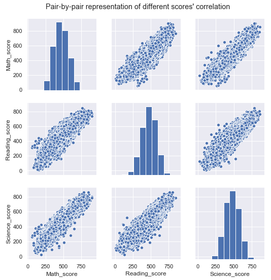

```python
# plot the pair scatter plots of Math_score, Reading_score, and Science_score

grid = sb.pairplot(data = pisa_home_clean, vars=["Math_score", "Reading_score", "Science_score"]);
grid.fig.suptitle("Pair-by-pair representation of different scores' correlation", y = 1.02);
```

There is a strong positive correlation between each pair of the three variables. Therefore, for the following two multivariate analysis, we will only plot the visualizations using Math_score.

### Math Score by Family Status and Country

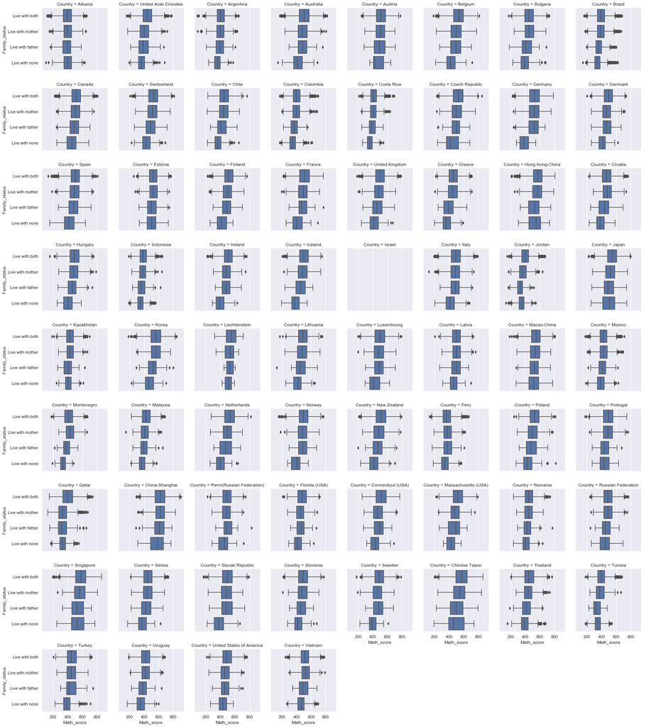

```python
# plot the facetgrid of math score by family_status and country

g = sb.FacetGrid(data = pisa_home_clean, col = 'Country', col_wrap = 8)
g.map(sb.boxplot, 'Math_score', 'Family_status')
```

The Facetgrid plot shows that in most countries, students in homes with two parents do better in all three subjects. Exceptions can be observed for Montenegro, Peru, and Vietnam. In these countries, students live with mother only score higher than students who live with both parents. One possible reason may be that fathers in these countries failed to put enough effort in children's education.

As observed in bivariate exploration, students with neither parent living at home have the lowest achievement in most countries, except for Estonia, Hong Kong-China, Jordan, Japan, Singapore, Tunisia. Among these exceptions, Estonia, Hong Kong-China, Japan, and Singapore rank high in the test, while Jordan and Tunisia rank very low. The reasons can be explored in future study by taking into account other variables.

### Math Score by Parent Employment Status and Country

```python
# set country_index with descending order of math score

grouped = pisa_home_clean.groupby('Country')['Math_score'].mean()
country_ordered = grouped.sort_values(ascending=False)
country_index= country_ordered.index
```

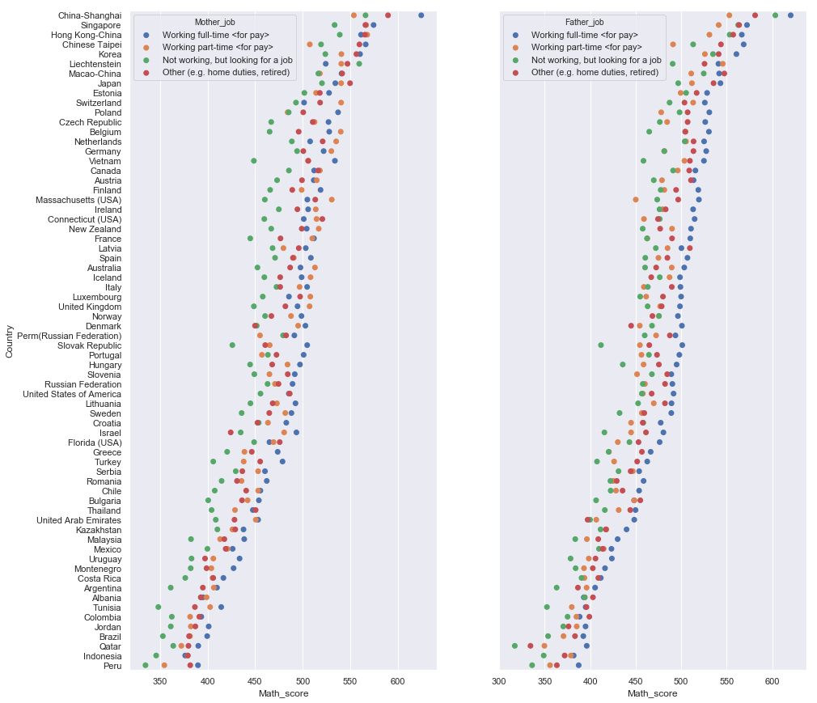

```python
# generate point plots of math score by mother_job/father_job across countries

plt.figure(figsize = [15,15])
plt.subplot(1, 2, 1)
sb.pointplot(data = pisa_home_clean, x = 'Math_score', y = 'Country', hue = 'Mother_job', linestyles = "",
                  pallete = 'mako', ci = None, order = country_index, scale = 0.8)
plt.subplot(1, 2, 2)
sb.pointplot(data = pisa_home_clean, x = 'Math_score', y = 'Country', hue = 'Father_job', linestyles = "",
                  pallete = 'viridis_r', ci = None, order = country_index, scale = 0.8)
plt.yticks([])
plt.ylabel('')
```

Parent employment status is also an important predictor of academic achievement. The pointplots of math score on this categorical variable across countries indicate that in most countries, students with fully employed fathers do best in tests, while students with fathers who is not working but looking for a job score lowest. Having a mother who works part-time or full-time is associated with high scores, while a stay-at-home (Other) parent does not improve scores. An exception can be observed from Liechtenstein, ranking 6th in math test. In Liechtenstein, the highest scores come from students with non-working mothers or part-time working fathers. Further exploration is required to reveal the reason.

## Conclusions and answers

### Talk about some of the relationships you observed in this part of the investigation. Were there features that strengthened each other in terms of looking at your feature(s) of interest?

In this section, the positive correlationship between Math_score, Reading_score, and Science_score is identifed. I also extended my investigation of the influence of family-based factors on test scores by looking at the impact of country. The multivariate exploration here showed that the general influence of family-based factors is valid for most countries, with a few exceptions. Since we only focus of family-based factors in this study, there could be other factors such as school factors or society factors that make the divergence.